# modeling

```python
from src.data_eng.datarequest import Series_requests
import pandas as pd
import numpy as np
import matplotlib.pyplot as plt
import seaborn as sns
import statsmodels.api as sm
from statsmodels.graphics.tsaplots import plot_acf
from sklearn.ensemble import AdaBoostRegressor, RandomForestRegressor, HistGradientBoostingRegressor
from sklearn.tree import DecisionTreeRegressor
from xgboost import XGBRegressor
from src.analytics.Metrics import Model_Metrics
import optuna
from sklearn.metrics import r2_score, mean_absolute_error
import os
from statsmodels.regression.linear_model import WLS
from statsmodels.graphics.gofplots import qqplot


import warnings
warnings.filterwarnings('ignore')
```

```python
data_path = os.path.join('..', 'data', 'dados_historicos_credit_portfolio.csv')
df = pd.read_csv(data_path)
```

```python
df['data'] = pd.to_datetime(df['data'])
df = df.set_index('data')
```

```python
df = df.dropna()
```

```python
df
```

| data | Saldo da carteira de crédito | IPCA | Taxa de desocupação (PNADC) | Endividamento das famílias(RNDBF) | Inadimplência da carteira de crédito | Selic (M) | PIB (M) | Taxa média mensal de juros não rotativo | IBC-BR | Prazo médio das concessões de crédito |
| --- | --- | --- | --- | --- | --- | --- | --- | --- | --- | --- |
| 2012-03-01 | 953171 | 0.21 | 8.0 | 36.87 | 5.36 | 0.82 | 397757.8 | 2.53 | 102.72490 | 105.95 |
| 2012-04-01 | 964854 | 0.64 | 7.8 | 36.99 | 5.41 | 0.71 | 385882.7 | 2.49 | 98.16340 | 106.70 |
| 2012-05-01 | 980828 | 0.36 | 7.7 | 37.21 | 5.51 | 0.74 | 401863.7 | 2.36 | 101.46906 | 108.51 |
| 2012-06-01 | 994137 | 0.08 | 7.6 | 37.42 | 5.43 | 0.64 | 395379.2 | 2.31 | 99.86712 | 110.43 |
| 2012-07-01 | 1004184 | 0.43 | 7.5 | 37.54 | 5.42 | 0.68 | 409024.9 | 2.26 | 103.50475 | 111.51 |
| ... | ... | ... | ... | ... | ... | ... | ... | ... | ... | ... |
| 2025-07-01 | 4188077 | 0.26 | 5.6 | 48.64 | 4.54 | 1.28 | 1095262.0 | 2.61 | 113.23431 | 181.18 |
| 2025-08-01 | 4226068 | -0.11 | 5.6 | 48.93 | 4.79 | 1.16 | 1066136.7 | 2.62 | 110.48903 | 179.72 |
| 2025-09-01 | 4260447 | 0.48 | 5.6 | 49.08 | 4.76 | 1.22 | 1074308.9 | 2.61 | 109.54869 | 180.79 |
| 2025-10-01 | 4319957 | 0.09 | 5.4 | 49.29 | 4.86 | 1.28 | 1103439.2 | 2.63 | 109.90366 | 180.96 |
| 2025-11-01 | 4381134 | 0.18 | 5.2 | 49.77 | 4.93 | 1.05 | 1083392.1 | 2.70 | 106.72339 | 181.81 |

165 rows × 10 columns

```python
df_train = df.iloc[:153]
df_train
```

| data | Saldo da carteira de crédito | IPCA | Taxa de desocupação (PNADC) | Endividamento das famílias(RNDBF) | Inadimplência da carteira de crédito | Selic (M) | PIB (M) | Taxa média mensal de juros não rotativo | IBC-BR | Prazo médio das concessões de crédito |
| --- | --- | --- | --- | --- | --- | --- | --- | --- | --- | --- |
| 2012-03-01 | 953171 | 0.21 | 8.0 | 36.87 | 5.36 | 0.82 | 397757.8 | 2.53 | 102.72490 | 105.95 |
| 2012-04-01 | 964854 | 0.64 | 7.8 | 36.99 | 5.41 | 0.71 | 385882.7 | 2.49 | 98.16340 | 106.70 |
| 2012-05-01 | 980828 | 0.36 | 7.7 | 37.21 | 5.51 | 0.74 | 401863.7 | 2.36 | 101.46906 | 108.51 |
| 2012-06-01 | 994137 | 0.08 | 7.6 | 37.42 | 5.43 | 0.64 | 395379.2 | 2.31 | 99.86712 | 110.43 |
| 2012-07-01 | 1004184 | 0.43 | 7.5 | 37.54 | 5.42 | 0.68 | 409024.9 | 2.26 | 103.50475 | 111.51 |
| ... | ... | ... | ... | ... | ... | ... | ... | ... | ... | ... |
| 2024-07-01 | 3744082 | 0.38 | 6.8 | 47.85 | 3.70 | 0.91 | 1018642.6 | 2.37 | 111.60730 | 173.96 |
| 2024-08-01 | 3790764 | -0.02 | 6.6 | 48.06 | 3.74 | 0.87 | 1003839.5 | 2.35 | 110.09557 | 174.08 |
| 2024-09-01 | 3831806 | 0.44 | 6.4 | 48.03 | 3.75 | 0.84 | 993453.8 | 2.36 | 107.08399 | 173.86 |
| 2024-10-01 | 3877157 | 0.56 | 6.2 | 48.08 | 3.70 | 0.93 | 1045302.1 | 2.37 | 109.19055 | 174.75 |
| 2024-11-01 | 3929256 | 0.39 | 6.1 | 48.30 | 3.66 | 0.79 | 1019260.5 | 2.40 | 105.40640 | 175.56 |

153 rows × 10 columns

```python
data_test = df.iloc[153:]
data_test
```

| data | Saldo da carteira de crédito | IPCA | Taxa de desocupação (PNADC) | Endividamento das famílias(RNDBF) | Inadimplência da carteira de crédito | Selic (M) | PIB (M) | Taxa média mensal de juros não rotativo | IBC-BR | Prazo médio das concessões de crédito |
| --- | --- | --- | --- | --- | --- | --- | --- | --- | --- | --- |
| 2024-12-01 | 3965534 | 0.52 | 6.2 | 48.44 | 3.54 | 0.93 | 999160.6 | 2.41 | 104.08432 | 177.65 |
| 2025-01-01 | 4013980 | 0.16 | 6.5 | 48.63 | 3.78 | 1.01 | 958037.7 | 2.47 | 102.89616 | 176.46 |
| 2025-02-01 | 4040708 | 1.31 | 6.8 | 48.61 | 3.85 | 0.99 | 994436.6 | 2.54 | 106.97556 | 177.17 |
| 2025-03-01 | 4083812 | 0.56 | 7.0 | 48.97 | 3.91 | 0.96 | 1072248.6 | 2.57 | 114.19661 | 174.36 |
| 2025-04-01 | 4116655 | 0.43 | 6.6 | 48.88 | 4.13 | 1.06 | 1087566.1 | 2.60 | 112.58813 | 178.26 |
| 2025-05-01 | 4133403 | 0.26 | 6.2 | 48.88 | 4.24 | 1.14 | 1062656.9 | 2.62 | 108.57626 | 179.72 |
| 2025-06-01 | 4155742 | 0.24 | 5.8 | 48.81 | 4.29 | 1.10 | 1050122.0 | 2.64 | 107.25421 | 181.02 |
| 2025-07-01 | 4188077 | 0.26 | 5.6 | 48.64 | 4.54 | 1.28 | 1095262.0 | 2.61 | 113.23431 | 181.18 |
| 2025-08-01 | 4226068 | -0.11 | 5.6 | 48.93 | 4.79 | 1.16 | 1066136.7 | 2.62 | 110.48903 | 179.72 |
| 2025-09-01 | 4260447 | 0.48 | 5.6 | 49.08 | 4.76 | 1.22 | 1074308.9 | 2.61 | 109.54869 | 180.79 |
| 2025-10-01 | 4319957 | 0.09 | 5.4 | 49.29 | 4.86 | 1.28 | 1103439.2 | 2.63 | 109.90366 | 180.96 |
| 2025-11-01 | 4381134 | 0.18 | 5.2 | 49.77 | 4.93 | 1.05 | 1083392.1 | 2.70 | 106.72339 | 181.81 |

```python
X = df_train.drop('Saldo da carteira de crédito', axis=1)
y = df_train['Saldo da carteira de crédito']
```

```python
data_test = data_test.dropna()
X_test = data_test.drop('Saldo da carteira de crédito', axis=1)
y_test = data_test['Saldo da carteira de crédito']
```

```python
X_test
```

| data | IPCA | Taxa de desocupação (PNADC) | Endividamento das famílias(RNDBF) | Inadimplência da carteira de crédito | Selic (M) | PIB (M) | Taxa média mensal de juros não rotativo | IBC-BR | Prazo médio das concessões de crédito |
| --- | --- | --- | --- | --- | --- | --- | --- | --- | --- |
| 2024-12-01 | 0.52 | 6.2 | 48.44 | 3.54 | 0.93 | 999160.6 | 2.41 | 104.08432 | 177.65 |
| 2025-01-01 | 0.16 | 6.5 | 48.63 | 3.78 | 1.01 | 958037.7 | 2.47 | 102.89616 | 176.46 |
| 2025-02-01 | 1.31 | 6.8 | 48.61 | 3.85 | 0.99 | 994436.6 | 2.54 | 106.97556 | 177.17 |
| 2025-03-01 | 0.56 | 7.0 | 48.97 | 3.91 | 0.96 | 1072248.6 | 2.57 | 114.19661 | 174.36 |
| 2025-04-01 | 0.43 | 6.6 | 48.88 | 4.13 | 1.06 | 1087566.1 | 2.60 | 112.58813 | 178.26 |
| 2025-05-01 | 0.26 | 6.2 | 48.88 | 4.24 | 1.14 | 1062656.9 | 2.62 | 108.57626 | 179.72 |
| 2025-06-01 | 0.24 | 5.8 | 48.81 | 4.29 | 1.10 | 1050122.0 | 2.64 | 107.25421 | 181.02 |
| 2025-07-01 | 0.26 | 5.6 | 48.64 | 4.54 | 1.28 | 1095262.0 | 2.61 | 113.23431 | 181.18 |
| 2025-08-01 | -0.11 | 5.6 | 48.93 | 4.79 | 1.16 | 1066136.7 | 2.62 | 110.48903 | 179.72 |
| 2025-09-01 | 0.48 | 5.6 | 49.08 | 4.76 | 1.22 | 1074308.9 | 2.61 | 109.54869 | 180.79 |
| 2025-10-01 | 0.09 | 5.4 | 49.29 | 4.86 | 1.28 | 1103439.2 | 2.63 | 109.90366 | 180.96 |
| 2025-11-01 | 0.18 | 5.2 | 49.77 | 4.93 | 1.05 | 1083392.1 | 2.70 | 106.72339 | 181.81 |

```
======================================================================================================================================================
Arvore de decisão: métricas de treino
    R²  MAE  MSE  MAPE(%)
0  1.0  0.0  0.0      0.0
Arvore de decisão: métricas de teste
         R²            MAE           MSE   MAPE(%)
0 -6.668151  313925.583333  1.095323e+11  0.074973
======================================================================================================================================================
======================================================================================================================================================
Random forest: métricas de treino
         R²          MAE           MSE   MAPE(%)
0  0.999598  9974.311176  2.652396e+08  0.004732
Random forest: métricas de teste
          R²            MAE           MSE   MAPE(%)
0 -21.046905  541236.048333  3.149192e+11  0.129325
======================================================================================================================================================
======================================================================================================================================================
Histboost: métricas de treino
        R²           MAE           MSE  MAPE(%)
0  0.99815  21787.842247  1.222447e+09  0.01032
Histboost: métricas de teste
          R²            MAE           MSE   MAPE(%)
0 -12.976212  433825.257944  1.996370e+11  0.103716
======================================================================================================================================================
======================================================================================================================================================
Xgboost: métricas de treino
    R²       MAE         MSE   MAPE(%)
0  1.0  7.457108  110.502678  0.000004
Xgboost: métricas de teste
         R²           MAE           MSE   MAPE(%)
0 -6.126268  304750.71875  1.017920e+11  0.072941
======================================================================================================================================================
```

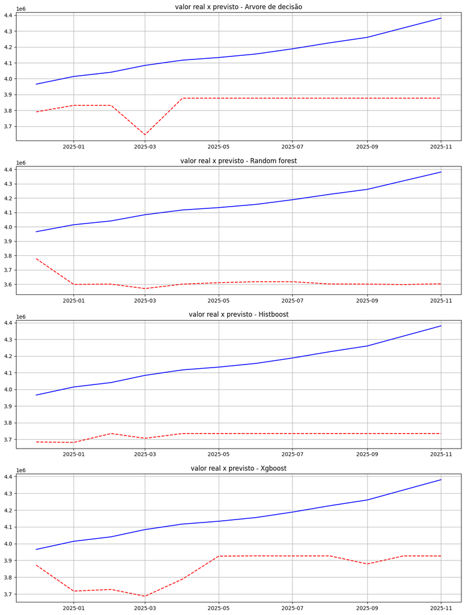

```python
# treinando modelos
models = {
    'Arvore de decisão': DecisionTreeRegressor(random_state=42),
    'Random forest': RandomForestRegressor(random_state=42),
    #'Adaboost':AdaBoostRegressor(random_state=42),
    'Histboost':HistGradientBoostingRegressor(random_state=42),
    'Xgboost':XGBRegressor()
}
fig, ax = plt.subplots(len(models), 1, figsize=(15, 2 * len(df.columns)))

for (i, model), axes in zip(models.items(), ax):
    model_ = model.fit(X, y)
    y_pred = model.predict(X)
    y_pred = pd.Series(y_pred, index=X.index, name='y_pred')
    print('==='*50)

    print(f'{i}: métricas de treino')
    metrics_train = Model_Metrics(y_pred, y)
    print(metrics_train.metrics())

    print(f'{i}: métricas de teste')
    y_pred_test = model_.predict(X_test)
    y_pred_test = pd.Series(y_pred_test, index=X_test.index, name='y_pred_test')
    metrics_test = Model_Metrics(y_pred_test, y_test)
    print(metrics_test.metrics())
    print('==='*50)

    axes.set_title(f'valor real x previsto - {i}')
    axes.plot(y_test, label='real', color='blue')
    axes.plot(y_pred_test, label='previsto - teste', color='red', linestyle='--')
    axes.grid()
```

```
SHAP modelo - Arvore de decisão
```

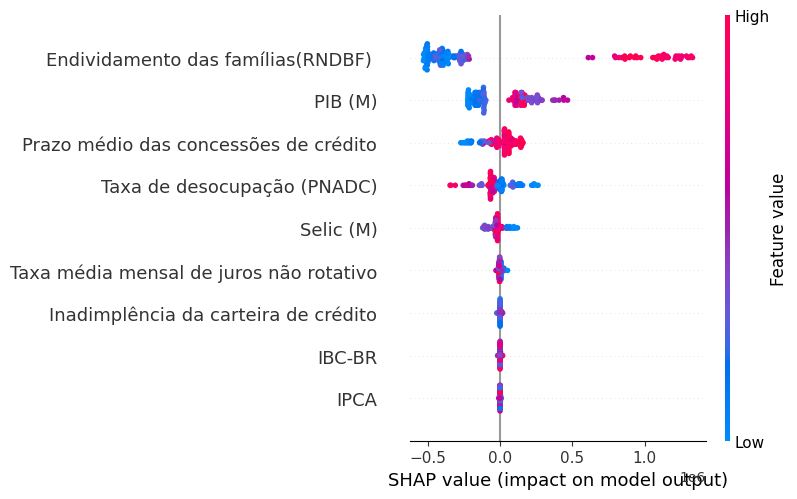

```
SHAP modelo - Random forest
```

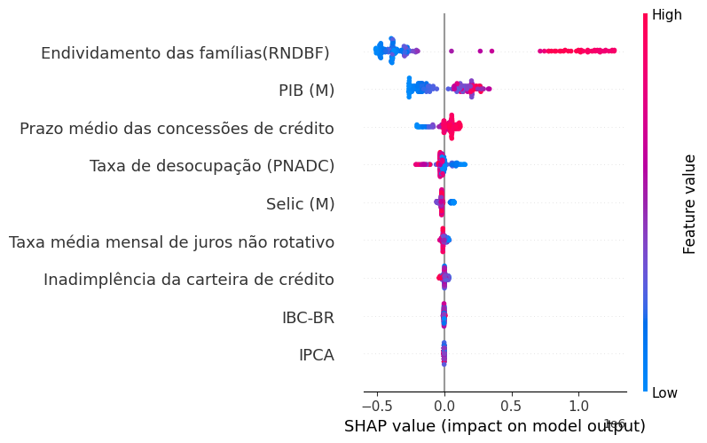

```
SHAP modelo - Histboost
```

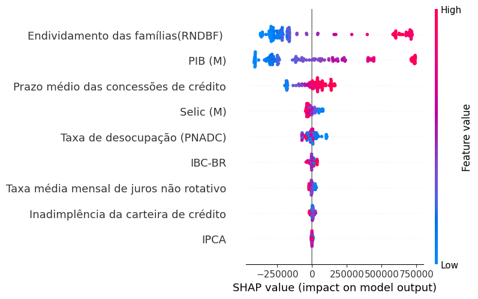

```
SHAP modelo - Xgboost
```

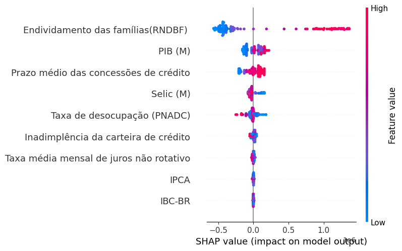

```python
for i, shap in models.items():
    model = shap.fit(X, y)
    pred_shap = model.predict(X)
    print(f'SHAP modelo - {i}')
    Model_Metrics(pred_shap, y).plot_shap(shap, X)
```

```
const                                      1.544242e+06
IPCA                                      -2.091357e+05
Taxa de desocupação (PNADC)               -1.782581e+04
Endividamento das famílias(RNDBF)          2.737524e+04
Inadimplência da carteira de crédito      -2.176568e+05
Selic (M)                                  8.247187e+05
PIB (M)                                    3.031878e+00
Taxa média mensal de juros não rotativo   -8.818517e+05
IBC-BR                                    -4.578285e+03
Prazo médio das concessões de crédito      2.753135e+03
dtype: float64
```

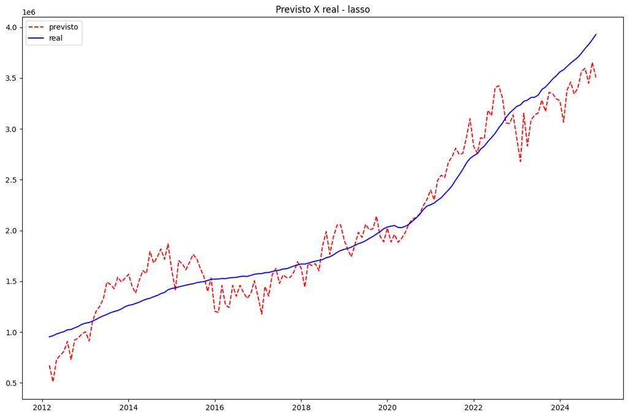

```python
# rodando modelo lasso
lasso = sm.OLS(y, sm.add_constant(X)).fit_regularized(method='elastic_net', L1_wt=1, alpha=0.1)
print(lasso.params)
lasso_pred = lasso.predict(sm.add_constant(X))
plt.figure(figsize=(12,8))
plt.title('Previsto X real - lasso')
plt.plot(lasso_pred, color='red', linestyle='--', label='previsto')
plt.plot(y, color='blue', label='real')
plt.tight_layout()
plt.legend()
plt.show()
```

```
-2159.285535580401
221480.62855792503
```

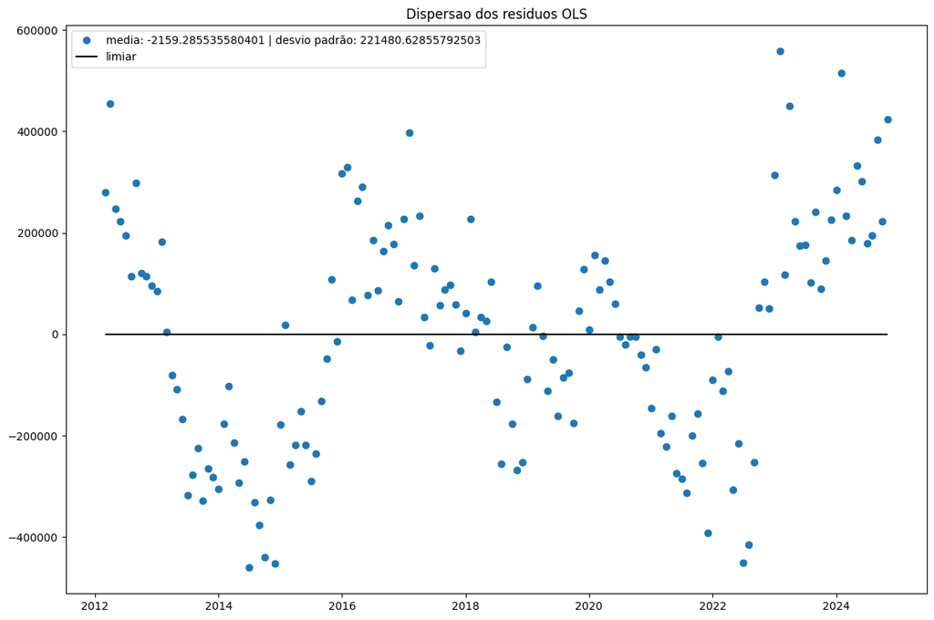

```python
resid = y - lasso_pred
print(resid.mean())
print(resid.std())
plt.figure(figsize=(12,8))
plt.title('Dispersao dos residuos OLS')
plt.plot(resid, marker='o', linestyle='none', label=f'media: {resid.mean()} | desvio padrão: {resid.std()}')
plt.hlines(y=0, xmin=y.index.min(), xmax=y.index.max(), color='black', label='limiar')
plt.legend()
plt.tight_layout()
plt.show()
```

```python
# metricas globais lasso
metrics = Model_Metrics(lasso_pred, y)
print(metrics.metrics())
```

```
         R²            MAE           MSE  MAPE(%)
0  0.926224  182558.496411  4.873772e+10   0.1036
```

Por mais que apresente métricas globais consistentes, tolerancia a multicolinearidade e robustez estatistica, o lasso nao vai ser util nesse trabalho. O motivo é a presença de heterocedasticidade, evidenciada graficamente por sua grande mudança de variaçao em relaçao ao tempo.

```python
model_wls = WLS(y, sm.add_constant(X)).fit_regularized(method='elastic_net', alpha=1, L1_wt=0)
wls_pred = model_wls.predict(sm.add_constant(X))
print(model_wls.params)
print()
print('metrica de treino:')
print()
print(Model_Metrics(wls_pred, y).metrics())
```

[output not shown]

Mudança em relaçao ao estudo:

A minha ideia inicial era, atraves de simulaçoes via Monte Carlo e picos e choques, estimar um intervalo médio para possiveis trajetorias do valor pontual da carteira de crédito. Porem, pela limitaçao das escalas e problemas com as estruturas numericas, me vejo mais interessado em explorar a estimativa da TAXA DE VARIAÇAO do sinal de crédito, utilizando log das diferenças.

```python
def log_diff(data:pd.DataFrame):
    log=np.log(data).diff()
    return log.fillna(log.mean())


data_diff = df_train.copy()
data_diff = log_diff(data_diff)
data_diff
```

| data | Saldo da carteira de crédito | IPCA | Taxa de desocupação (PNADC) | Endividamento das famílias(RNDBF) | Inadimplência da carteira de crédito | Selic (M) | PIB (M) | Taxa média mensal de juros não rotativo | IBC-BR | Prazo médio das concessões de crédito |
| --- | --- | --- | --- | --- | --- | --- | --- | --- | --- | --- |
| 2012-03-01 | 0.009318 | 0.007618 | -0.001784 | 0.001777 | -0.002510 | -0.000245 | 0.006191 | -0.000347 | 0.000170 | 0.003322 |
| 2012-04-01 | 0.012182 | 1.114361 | -0.025318 | 0.003249 | 0.009285 | -0.144039 | -0.030310 | -0.015937 | -0.045421 | 0.007054 |
| 2012-05-01 | 0.016420 | -0.575364 | -0.012903 | 0.005930 | 0.018316 | 0.041385 | 0.040580 | -0.053621 | 0.033120 | 0.016821 |
| 2012-06-01 | 0.013478 | -1.504077 | -0.013072 | 0.005628 | -0.014625 | -0.145182 | -0.016268 | -0.021414 | -0.015913 | 0.017540 |
| 2012-07-01 | 0.010056 | 1.681759 | -0.013245 | 0.003202 | -0.001843 | 0.060625 | 0.033931 | -0.021883 | 0.035777 | 0.009732 |
| ... | ... | ... | ... | ... | ... | ... | ... | ... | ... | ... |
| 2024-07-01 | 0.010746 | 0.593064 | -0.014599 | 0.003769 | 0.021859 | 0.141412 | 0.042898 | -0.004211 | 0.053791 | -0.002583 |
| 2024-08-01 | 0.012391 | 0.007618 | -0.029853 | 0.004379 | 0.010753 | -0.044951 | -0.014639 | -0.008475 | -0.013638 | 0.000690 |
| 2024-09-01 | 0.010769 | 0.007618 | -0.030772 | -0.000624 | 0.002670 | -0.035091 | -0.010400 | 0.004246 | -0.027735 | -0.001265 |
| 2024-10-01 | 0.011766 | 0.241162 | -0.031749 | 0.001040 | -0.013423 | 0.101783 | 0.050874 | 0.004228 | 0.019481 | 0.005106 |
| 2024-11-01 | 0.013348 | -0.361790 | -0.016261 | 0.004565 | -0.010870 | -0.163152 | -0.025229 | 0.012579 | -0.035271 | 0.004624 |

153 rows × 10 columns

```python
X_diff = data_diff.drop('Saldo da carteira de crédito', axis=1)
y_diff = data_diff['Saldo da carteira de crédito']
```

```python
wls_diff_model = WLS(y_diff, sm.add_constant(X_diff)).fit()
print(wls_diff_model.summary())
```

```
                                 WLS Regression Results
========================================================================================
Dep. Variable:     Saldo da carteira de crédito   R-squared:                       0.579
Model:                                      WLS   Adj. R-squared:                  0.552
Method:                           Least Squares   F-statistic:                     21.83
Date:                          Mon, 09 Feb 2026   Prob (F-statistic):           6.40e-23
Time:                                  22:11:01   Log-Likelihood:                 646.71
No. Observations:                           153   AIC:                            -1273.
Df Residuals:                               143   BIC:                            -1243.
Df Model:                                     9
Covariance Type:                      nonrobust
===========================================================================================================
                                              coef    std err          t      P>|t|      [0.025      0.975]
-----------------------------------------------------------------------------------------------------------
const                                       0.0084      0.000     23.175      0.000       0.008       0.009
IPCA                                        0.0004      0.000      1.024      0.308      -0.000       0.001
Taxa de desocupação (PNADC)                -0.0642      0.012     -5.536      0.000      -0.087      -0.041
Endividamento das famílias(RNDBF)           0.4062      0.049      8.223      0.000       0.309       0.504
Inadimplência da carteira de crédito       -0.0201      0.013     -1.528      0.129      -0.046       0.006
Selic (M)                                   0.0064      0.003      1.984      0.049     2.4e-05       0.013
PIB (M)                                    -0.0340      0.024     -1.405      0.162      -0.082       0.014
Taxa média mensal de juros não rotativo    -0.0026      0.016     -0.167      0.867      -0.033       0.028
IBC-BR                                      0.0490      0.026      1.864      0.064      -0.003       0.101
Prazo médio das concessões de crédito       0.0661      0.036      1.816      0.071      -0.006       0.138
==============================================================================
Omnibus:                        3.924   Durbin-Watson:                   0.988
Prob(Omnibus):                  0.141   Jarque-Bera (JB):                3.436
Skew:                           0.342   Prob(JB):                        0.179
Kurtosis:                       3.268   Cond. No.                         171.
==============================================================================

Notes:
[1] Standard Errors assume that the covariance matrix of the errors is correctly specified.
```

```python
# separando treino-teste
X_test_diff = X_test.copy()
X_test_diff = log_diff(X_test_diff)
X_test_diff
```

| data | IPCA | Taxa de desocupação (PNADC) | Endividamento das famílias(RNDBF) | Inadimplência da carteira de crédito | Selic (M) | PIB (M) | Taxa média mensal de juros não rotativo | IBC-BR | Prazo médio das concessões de crédito |
| --- | --- | --- | --- | --- | --- | --- | --- | --- | --- |
| 2024-12-01 | -0.185997 | -0.015990 | 0.002462 | 0.030110 | 0.011033 | 0.007358 | 0.010330 | 0.002276 | 0.002104 |
| 2025-01-01 | -1.178655 | 0.047253 | 0.003915 | 0.065597 | 0.082521 | -0.042028 | 0.024591 | -0.011481 | -0.006721 |
| 2025-02-01 | 2.102609 | 0.045120 | -0.000411 | 0.018349 | -0.020001 | 0.037289 | 0.027946 | 0.038880 | 0.004016 |
| 2025-03-01 | -0.849846 | 0.028988 | 0.007379 | 0.015464 | -0.030772 | 0.075337 | 0.011742 | 0.065321 | -0.015988 |
| 2025-04-01 | -0.264152 | -0.058841 | -0.001840 | 0.054740 | 0.099091 | 0.014184 | 0.011606 | -0.014185 | 0.022121 |
| 2025-05-01 | -0.503104 | -0.062520 | 0.000000 | 0.026286 | 0.072759 | -0.023170 | 0.007663 | -0.036284 | 0.008157 |
| 2025-06-01 | -0.080043 | -0.066691 | -0.001433 | 0.011723 | -0.035718 | -0.011866 | 0.007605 | -0.012251 | 0.007207 |
| 2025-07-01 | 0.080043 | -0.035091 | -0.003489 | 0.056640 | 0.151550 | 0.042087 | -0.011429 | 0.054257 | 0.000883 |
| 2025-08-01 | -0.185997 | 0.000000 | 0.005944 | 0.053603 | -0.098440 | -0.026952 | 0.003824 | -0.024543 | -0.008091 |
| 2025-09-01 | -0.185997 | 0.000000 | 0.003061 | -0.006283 | 0.050431 | 0.007636 | -0.003824 | -0.008547 | 0.005936 |
| 2025-10-01 | -1.673976 | -0.036368 | 0.004270 | 0.020791 | 0.048009 | 0.026754 | 0.007634 | 0.003235 | 0.000940 |
| 2025-11-01 | 0.693147 | -0.037740 | 0.009691 | 0.014301 | -0.198070 | -0.018335 | 0.026268 | -0.029364 | 0.004686 |

```python
y_test_diff = log_diff(y_test)
```

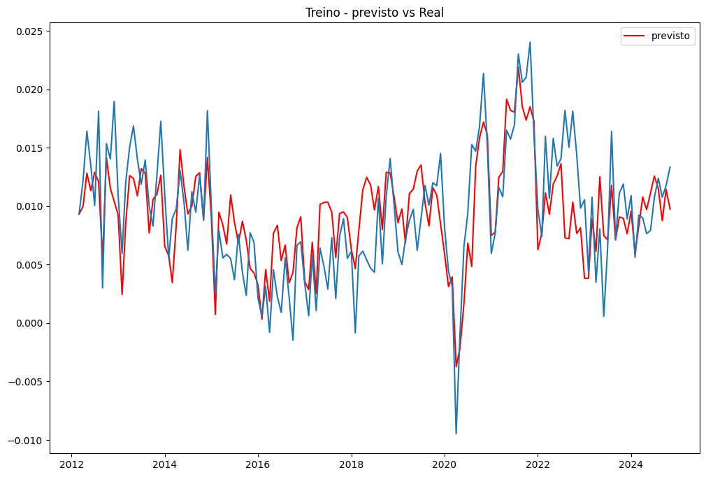

```python
y_pred_diff_train = wls_diff_model.predict(sm.add_constant(X_diff))
plt.figure(figsize=(12,8))
plt.title('Treino - previsto vs Real')
plt.plot(y_pred_diff_train, color='red', label='previsto')
plt.plot(y_diff)
plt.legend()
plt.show()
```

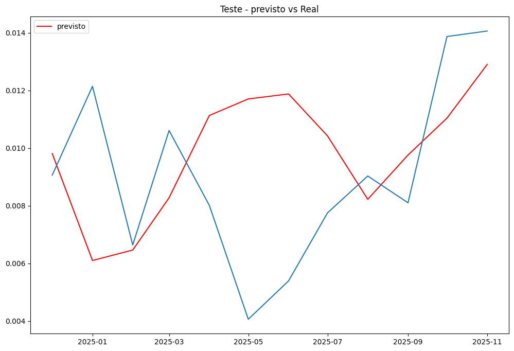

```python
y_pred_diff_test = wls_diff_model.predict(sm.add_constant(X_test_diff))
plt.figure(figsize=(12,8))
plt.title('Teste - previsto vs Real')
plt.plot(y_pred_diff_test, color='red', label='previsto')
plt.plot(y_test_diff)
plt.legend()
plt.show()
```

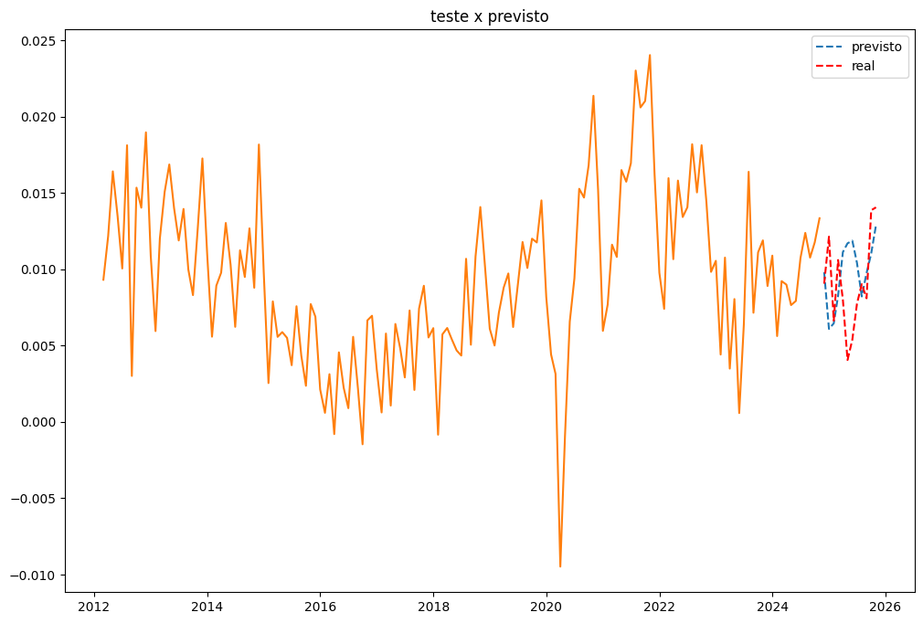

```python
plt.figure(figsize=(12,8))
plt.title('teste x previsto')
plt.plot(y_pred_diff_test, label='previsto', linestyle='--')
plt.plot(y_diff)
plt.plot(y_test_diff, label='real', linestyle='--', color='red')
plt.legend()
plt.show()
```

```python
resid_diff = wls_diff_model.resid
print(f'media residuos wls: {resid_diff.mean()}')
print(f'desvio padrao residuos wls: {resid_diff.std()}')
```

```
media residuos wls: -7.619177619976565e-18
desvio padrao residuos wls: 0.0035439603795346377
```

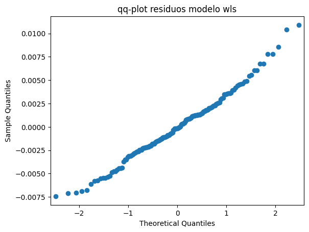

```python
qqplot(resid_diff)
plt.title('qq-plot residuos modelo wls')
plt.show()
```

Os residuos nao apresentam dispersão significativa que exponha heterocedasticidade severa. As caudas inferiores e superiores possuem pequenos desvios, mas nada que influencie a normalidade

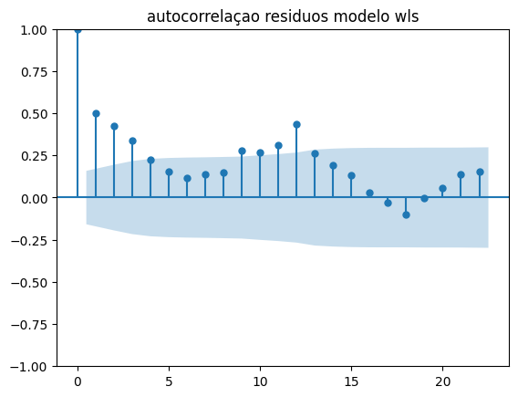

```python
# verificando autocorelaçao dos residuos
plot_acf(resid_diff)
plt.title('autocorrelaçao residuos modelo wls')
plt.figure(figsize=(12,8))
plt.show()
```

```python
print('metricas treino - log diff')
print(Model_Metrics(y_pred_diff_train, y_diff).metrics())
```

```
metricas treino - log diff
         R²       MAE       MSE   MAPE(%)
0  0.578804  0.002782  0.000012  0.591227
```

O mape nao é util por conta do espaço de variaçoes que estamos modelando

**Simulação de Monte Carlo**

Como ja definimos o modelo e asa tecnicas certas, irei modelar estimativas em simulaçoes via monte carlo.

Nosso modelo tera o papel de inferir atraves de N simulaçoes (cenarios: normal, otimista e pessimista) afim de estimar um possivel trajeto e intervalos de confiança para as estimativas

```python
# choques de estresse que iremos aplicar nos dados. Por exemplo: 0.3 ou 30% de choque na taxa de desocupaçao
stress_dict = {
    'IPCA': 0.25,
    'Taxa de desocupação (PNADC)': 0.4,
    'Endividamento das famílias(RNDBF) ': 0.2,
    'Inadimplência da carteira de crédito': 0.5,
    'Selic (M)':0.35,
    'PIB (M)': -0.3,
    'Taxa média mensal de juros não rotativo': 0.25,
    'IBC-BR': -0.35,
    'Prazo médio das concessões de crédito': -0.20
}

cols_sim = X.columns
```

Para cenarios de estresse, foi usado o seguinte critério:

**IPCA': 0.25** - inflação dispara (ex: 10% → 12.5%)

**'Taxa de desocupação (PNADC)'**: 0.40 - desemprego sobe forte (ex: 9% → 12.6%)

**'Endividamento das famílias(RNDBF)'**: 0.20 - famílias já endividadas recorrem mais a crédito

**'Inadimplência da carteira de crédito'**: 0.50 - choque pesado e realista em crises

**'Selic (M)'**: 0.35 - ciclo agressivo de aperto monetário

**'PIB (M)'**: -0.30 - recessão técnica profunda

**'Taxa média mensal de juros não rotativo'**: 0.25 - spreads sobem junto com a Selic

**'IBC-BR'**: -0.35 - atividade econômica despenca

**'Prazo médio das concessões de crédito'**: -0.20 - bancos encurtam prazos por risco

```python
from src.analytics.MonteCarlo import MonteCarlo
mc = MonteCarlo(1, X, 10000, cols_sim, stress_dict)
mc_norm = mc.normal_input()
mc_norm_diff = log_diff(mc_norm)
mc_norm_diff
```

```
CENÁRIO NORMAL | 10000 cenários | horizonte 252
```

|  | IPCA | Taxa de desocupação (PNADC) | Endividamento das famílias(RNDBF) | Inadimplência da carteira de crédito | Selic (M) | PIB (M) | Taxa média mensal de juros não rotativo | IBC-BR | Prazo médio das concessões de crédito |
| --- | --- | --- | --- | --- | --- | --- | --- | --- | --- |
| 0 | 0.000409 | 3.528586e-07 | -1.747711e-09 | 6.810762e-08 | -0.000051 | -0.000003 | 3.502450e-08 | 2.368379e-08 | -9.617619e-08 |
| 1 | 1.108306 | 1.833936e-01 | -1.102976e-01 | -1.490462e-01 | -0.151716 | -0.149831 | 1.011604e-01 | -1.060926e-01 | 1.092404e-01 |
| 2 | -0.231807 | -9.286018e-02 | 3.273578e-03 | 2.044110e-01 | 0.135665 | -0.326511 | 2.125106e-02 | 4.450641e-02 | -1.787253e-01 |
| 3 | 0.822230 | -5.250900e-02 | 3.017995e-02 | -1.520752e-01 | -0.891281 | 0.110933 | -4.128786e-01 | 3.096316e-02 | -1.279572e-01 |
| 4 | -0.131956 | -2.962750e-01 | -1.815555e-01 | 1.248953e-01 | 0.385378 | -0.613569 | 7.709651e-02 | 5.674201e-02 | -1.119058e-01 |
| ... | ... | ... | ... | ... | ... | ... | ... | ... | ... |
| 2519995 | -0.887693 | -1.767600e-01 | 3.571561e-01 | 6.973618e-02 | 0.700874 | 1.230237 | 1.434811e-01 | 9.522201e-02 | -9.575273e-03 |
| 2519996 | 0.787779 | 2.505144e-03 | 5.925850e-02 | -4.642250e-01 | -0.221532 | 0.061773 | -2.156646e-01 | -3.570906e-02 | 1.496452e-01 |
| 2519997 | -0.529535 | 5.552074e-01 | -1.462182e-01 | 2.822507e-01 | -0.188660 | -0.033348 | 2.461316e-01 | -4.499432e-02 | 8.101722e-02 |
| 2519998 | -1.896388 | -2.188925e-01 | 1.501264e-02 | 9.356487e-02 | -1.178468 | -0.013650 | -2.294930e-01 | 2.350390e-02 | -1.488030e-01 |
| 2519999 | 2.208259 | -1.123356e+00 | 6.702097e-02 | 2.601845e-01 | 1.788818 | -0.228414 | 1.281090e-01 | 1.482914e-01 | -2.835683e-01 |

2520000 rows × 9 columns

```python
mc_norm_pred = wls_diff_model.predict(sm.add_constant(mc_norm_diff))
mc_norm_pred
```

```
0          0.008412
1         -0.038875
2          0.013789
3          0.012083
4         -0.030373
             ...
2519995    0.129418
2519996    0.047133
2519997   -0.090060
2519998    0.010838
2519999    0.110723
Length: 2520000, dtype: float64
```

```python
def plot_sim(y:pd.Series):
    plt.figure(figsize=(12,8))
    plt.title('Distribuição das previsões simuladas')
    sns.histplot(y, kde=True)
    plt.axvline(y.quantile(0.05), color='black', label=f'inf: {np.round(y.quantile(0.05),3)} | sup: {np.round(y.quantile(0.95),3)}')
    plt.axvline(y.mean(), color='red', label=f'média:{np.round(y.mean(), 3)}')
    plt.axvline(y.quantile(0.95), color='black')
    plt.legend()
    plt.show()
```

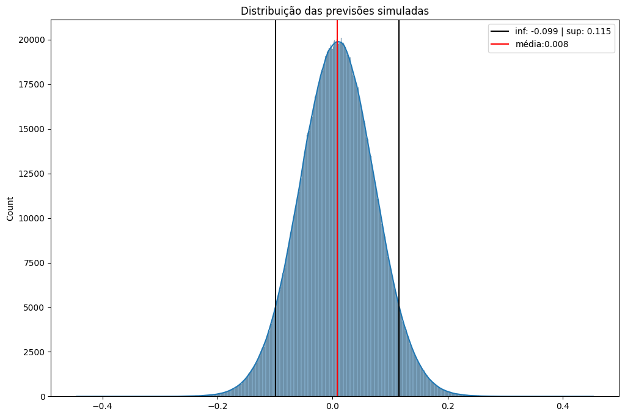

```python
plot_sim(mc_norm_pred) # cenario normal
```

```python
optimism_dict = {
    #'Saldo da carteira de crédito':0.3,
    'IPCA':-0.1,
    'Taxa de desocupação (PNADC)':-0.3,
    'Endividamento das famílias(RNDBF) ':-0.1,
    'Inadimplência da carteira de crédito':-0.2,
    'Selic (M)':-0.2,
    'PIB (M)':0.1,
    'Taxa média mensal de juros não rotativo':-0.04,
    'IBC-BR':0.1,
    'Prazo médio das concessões de crédito':-0.1
}

mc_optmism = mc.optimism(optimism_dict)
mc_optmism_diff = log_diff(mc_optmism)
```

```
CENÁRIO OTIMISTA | 10000 cenários
```

```python
mc_optmism_pred = wls_diff_model.predict(sm.add_constant(mc_optmism_diff))
mc_optmism_pred
```

```
0          0.008412
1          0.148015
2         -0.074984
3         -0.142047
4          0.133680
             ...
2519995   -0.134388
2519996    0.051230
2519997    0.014302
2519998   -0.102612
2519999    0.049973
Length: 2520000, dtype: float64
```

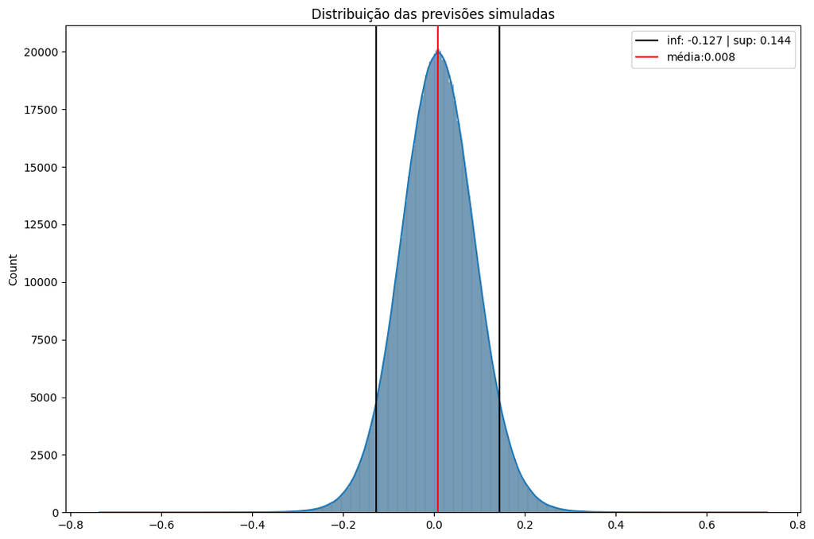

```python
plot_sim(mc_optmism_pred) # cenario de otimismo
```

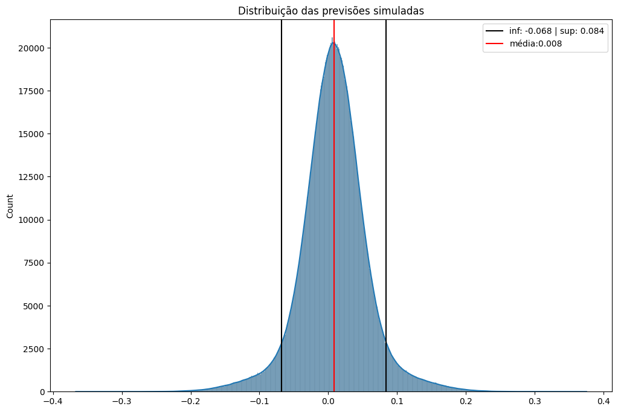

```python
plot_sim(mc_stress_pred) # cenario de estresse
```

[output not shown]

**Estimação de intervalos de confiança**

**-- Cenário Otimista --**

```python
""""funçao para a criaçao de intervalos de confiança
        sera usado para medir a eficiencia estatistica da média das previsoes do futuro modelo"""
from scipy.stats import t as t_student
def ic(conf:float, sample_data):
        sample = sample_data.sample(100)
        mean = sample.mean()
        std = sample.std()
        t = t_student.ppf(conf, len(sample)-1)
        sup = mean + t * std/(len(sample)**0.5)
        inf = mean - t * std/(len(sample)**0.5)

        return mean, std, sup, inf
```

```python
# pegando amostra das simulaçoes de monte carlo - otimismo
sample_opt = mc_optmism_pred.sample(1000)
sample_opt
```

```
1540530    0.141238
1844226   -0.029663
127260     0.105051
265346     0.225907
2332838    0.048279
             ...
926307     0.083819
826891     0.060313
1834384    0.124766
135803     0.079769
1563691    0.085878
Length: 1000, dtype: float64
```

```python
sample_list = []
for _ in range(100000):
    sim = ic(0.95, sample_opt)
    sample_list.append(sim)

df_conf_opt = pd.DataFrame(sample_list, columns=['mean', 'std', 'sup', 'inf'])
df_conf_opt['true_mean'] = np.round((mc_optmism_pred).mean(),3)
#df_conf['inf'] < df_conf['true_mean'] & (df_conf['sup'] > df_conf['true_mean'])
```

```python
df_conf_opt.sample(10)
```

|  | mean | std | sup | inf | true_mean |
| --- | --- | --- | --- | --- | --- |
| 96305 | 0.006614 | 0.078296 | 0.019614 | -0.006386 | 0.008 |
| 89943 | 0.007004 | 0.089324 | 0.021836 | -0.007827 | 0.008 |
| 61203 | 0.008239 | 0.080577 | 0.021617 | -0.005140 | 0.008 |
| 87342 | 0.009358 | 0.089419 | 0.024205 | -0.005489 | 0.008 |
| 57481 | 0.012038 | 0.081721 | 0.025607 | -0.001531 | 0.008 |
| 61604 | 0.022313 | 0.075491 | 0.034848 | 0.009779 | 0.008 |
| 1639 | 0.008024 | 0.086428 | 0.022374 | -0.006327 | 0.008 |
| 98907 | 0.004037 | 0.089281 | 0.018861 | -0.010787 | 0.008 |
| 17031 | 0.009371 | 0.070492 | 0.021075 | -0.002333 | 0.008 |
| 85045 | 0.008319 | 0.095208 | 0.024127 | -0.007489 | 0.008 |

```python
df_conf_opt['conf'] = (df_conf_opt['inf'] < df_conf_opt['true_mean']) & (df_conf_opt['sup'] > df_conf_opt['true_mean'])
```

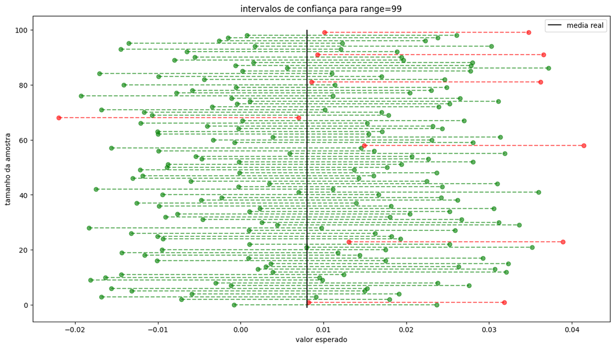

```
confiança de: 91.4%
```

```python
plt.figure(figsize=(15,8))
for i in range(100):
    data = df_conf_opt.iloc[i]
    color = 'green' if data['conf'] else 'red'
    plt.title(f'intervalos de confiança para range={i}')
    plt.plot(data[['inf', 'sup']], [i, i], 'o--', color=color, alpha=0.6)
plt.vlines(data['true_mean'].max(), -1, i+1, color='black', label='media real')
plt.xlabel('valor esperado')
plt.ylabel('tamanho da amostra')
plt.legend()
plt.show()
confiance_opt = df_conf_opt['conf'].sample(1000).mean()
print(f'confiança de: {confiance_opt*100}%')
```

**-- Cenário de estresse --**

```python
stress_sample = mc_stress_pred.sample(1000)
stress_list = []
for _ in range(10000):
    sim_stress = ic(0.95, stress_sample)
    stress_list.append(sim_stress)
df_conf_stress = pd.DataFrame(stress_list, columns=['mean', 'std', 'sup', 'inf'])
df_conf_stress['true_mean'] = mc_stress_pred.mean()
df_conf_stress['conf'] = (df_conf_stress['inf']<df_conf_stress['true_mean']) & (df_conf_stress['sup']>df_conf_stress['true_mean'])
```

[output not shown]

10000 rows × 6 columns

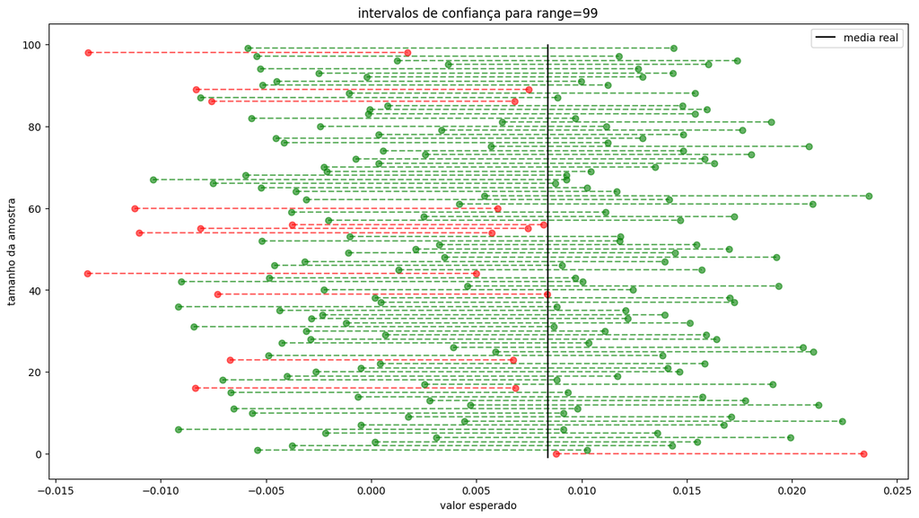

```
confiança de: 87.7%
```

```python
# plotando confianças para cenario de estresse
plt.figure(figsize=(15,8))
for j in range(100):
    data = df_conf_stress.iloc[j]
    color = 'green' if data['conf'] else 'red'
    plt.title(f'intervalos de confiança para range={j}')
    plt.plot(data[['inf', 'sup']], [j, j], 'o--', color=color, alpha=0.6)
plt.vlines(data['true_mean'].max(), -1, j+1, color='black', label='media real')
plt.xlabel('valor esperado')
plt.ylabel('tamanho da amostra')
plt.legend()
plt.show()
confiance_stress = df_conf_stress['conf'].sample(1000).mean()
print(f'confiança de: {confiance_stress*100}%')
```